# Step1. Generate MetaSpots (Visium HD)

In this vignette we aggregate Visium HD data into MetaSpots (or MetaBins) to reduce sparseness, and then run STEAM. The Seurat v5 object is analyzed at 16µm resolution, has already been filtered (removing genes < 10 UMIs and spots/bins with < 500 UMIs) and spatial clusters determined.

We use a mouse coronal section from 10X: https://www.10xgenomics.com/datasets/visium-hd-cytassist-gene-expression-mouse-brain-fresh-frozen

# 1 Load libraries

```r
library(Seurat)
library(arrow)
library(dplyr)
library(STEAM)
library(future)
```

# 2 Load data

Load Seurat object.

```r
se <- readRDS(file = "data/Visium_HD_mouse_coronal/mouse_coronal_HD_016um_filtered.rds")
se
```

```
## An object of class Seurat
## 16082 features across 113024 samples within 1 assay
## Active assay: Spatial.016um (16082 features, 0 variable features)
##  1 layer present: counts
##  1 spatial field of view present: slice1.016um
```

Load spatial clusters.

```r
se_spatial_clusters <- readRDS(file = "data/Visium_HD_mouse_coronal/mouse_coronal_HD_016um_spatial_clusters.rds")
head(se_spatial_clusters)
```

```
##                       seurat_cluster.016um
## s_016um_00107_00066-1                    3
## s_016um_00126_00213-1                   14
## s_016um_00158_00414-1                   12
## s_016um_00242_00130-1                    2
## s_016um_00230_00364-1                    4
## s_016um_00329_00125-1                    9
```

Add spatial clusters to Seurat object.

```r
se$seurat_cluster.016um <- se_spatial_clusters$seurat_cluster.016um
head(se[[]])
```

```
##                       orig.ident nCount_Spatial.016um nFeature_Spatial.016um
## s_016um_00107_00066-1          s                 1853                   1393
## s_016um_00126_00213-1          s                 5794                   3208
## s_016um_00158_00414-1          s                 3739                   2328
## s_016um_00242_00130-1          s                 2547                   1678
## s_016um_00230_00364-1          s                 5021                   2771
## s_016um_00329_00125-1          s                 3945                   2259
##                       seurat_cluster.016um
## s_016um_00107_00066-1                    3
## s_016um_00126_00213-1                   14
## s_016um_00158_00414-1                   12
## s_016um_00242_00130-1                    2
## s_016um_00230_00364-1                    4
## s_016um_00329_00125-1                    9
```

View spatial clusters.

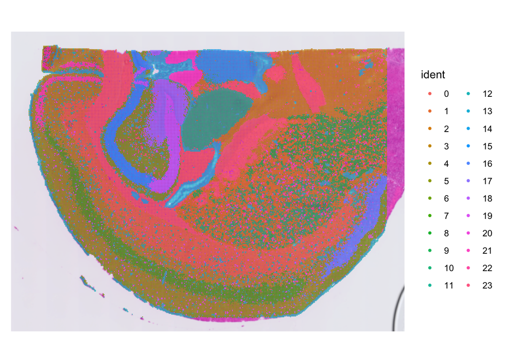

```r
se <- SetIdent(se, value = "seurat_cluster.016um")
SpatialDimPlot(se)
```

Check number of Genes and UMIs per spatial cluster.

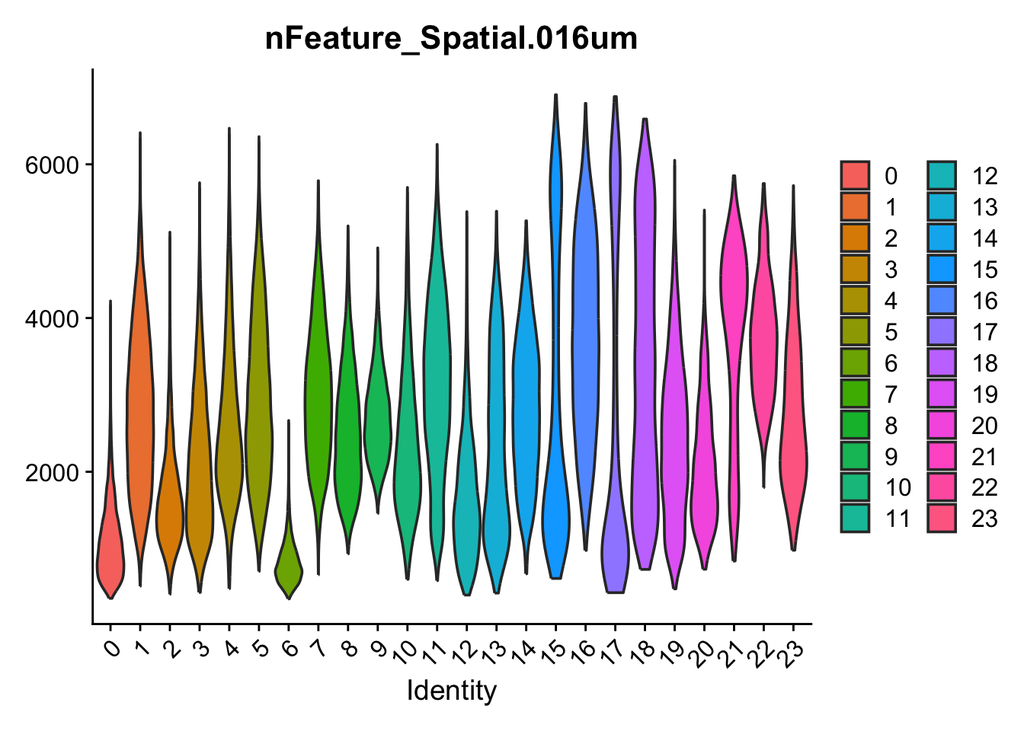

```r
VlnPlot(se, features = "nFeature_Spatial.016um", pt.size = 0, group.by = "seurat_cluster.016um")
```

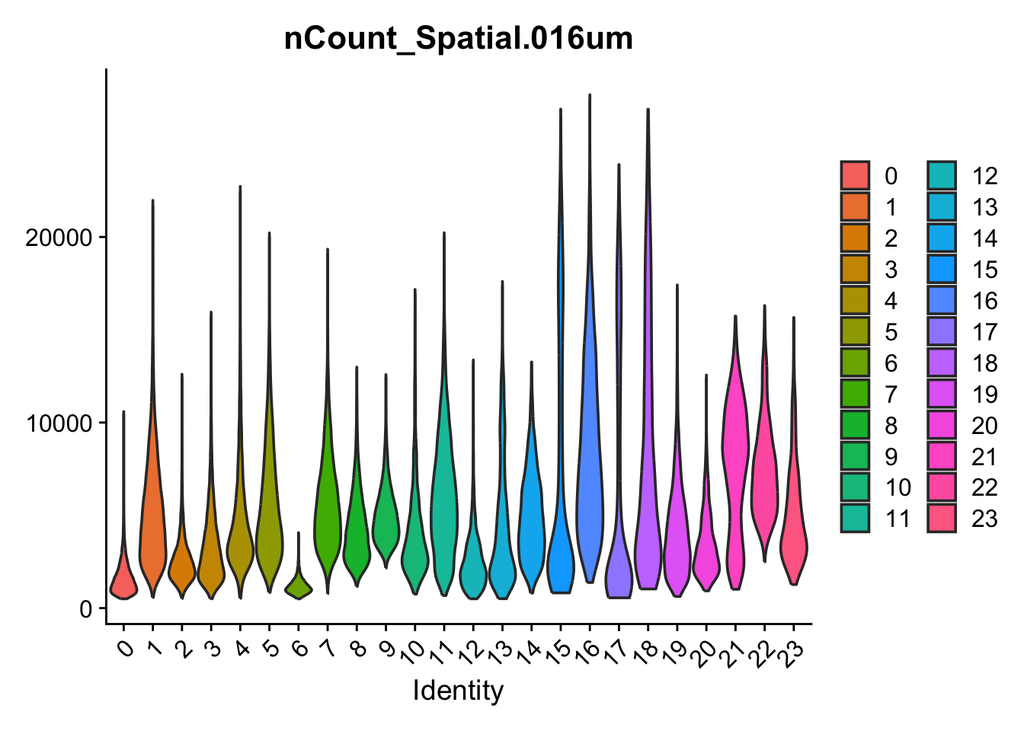

```r
VlnPlot(se, features = "nCount_Spatial.016um", pt.size = 0, group.by = "seurat_cluster.016um")
```

# 3 Generate MetaSpot clusters

Check number of spots/bins per spatial cluster of the cluster annotation you want to create MetaSpots (or MetaBins) from.

```r
table(se$seurat_cluster.016um)
```

```
##
##     0     1     2     3     4     5     6     7     8     9    10    11    12
## 12481 10725 10722 10454  7958  7566  7473  5513  5500  4167  3850  3721  3577
##    13    14    15    16    17    18    19    20    21    22    23
##  2843  2258  2245  2179  2152  1782  1697  1297  1041  1029   794
```

Add the spatial cluster metadata as a new slot called ‘cluster_anno’ for downstream processing.

```r
se$cluster_anno <- se$seurat_cluster.016um
table(se$cluster_anno)
```

```
##
##     0     1     2     3     4     5     6     7     8     9    10    11    12
## 12481 10725 10722 10454  7958  7566  7473  5513  5500  4167  3850  3721  3577
##    13    14    15    16    17    18    19    20    21    22    23
##  2843  2258  2245  2179  2152  1782  1697  1297  1041  1029   794
```

Here we want to generate MetaSpots (or MetaBins) from the spatial cluster annotation ‘cluster_anno’. The generate_metacell_clusters function subsets all spatial clusters into separate Seurat objects and then uses NormalizeData, FindVariableFeatures, ScaleData, RunPCA and FindNeighbors on each and saving them to a list. For each new Seurat object in the list the optimal sub-clustering resolution setting is iterated using the FindClusters function, starting at a user given initial resolution (initial_resolution) and moving by 0.1 while the average number of user give spots/bins per sub-cluster is less than ‘num_cells_per_metacell’. The generate_metacell_clusters iterations then reduces the sub-clustering resolution with 0.1 if the average number of user give spots/bins per sub-cluster (future MetaSpot/MetaBins) is more than num_cells_per_metacell, and then stops.

Please note that if the desired number of average spots/bins per sub-cluster is not possible the reach, the function will stall out. If that happens try using +/- 1 desired number of average spots/bins per sub-cluster and re-run.

```r
plan("sequential")

metaspots <- generate_metacell_clusters(
   se = se,
   cluster_anno = "cluster_anno",
   num_cells_per_metacell = 50,
   pca_dims = 10,
   initial_resolution = 0.1
 )
```

```
## [1] "Removed cell types with too few cells:"
## character(0)
```

```
##
## Processing cell type: 3
```

```
##
## Processing cell type: 14
```

```
##
## Processing cell type: 12
```

```
##
## Processing cell type: 2
```

```
##
## Processing cell type: 4
```

```
##
## Processing cell type: 9
```

```
##
## Processing cell type: 1
```

```
##
## Processing cell type: 0
```

```
##
## Processing cell type: 10
```

```
##
## Processing cell type: 15
```

```
##
## Processing cell type: 16
```

```
##
## Processing cell type: 8
```

```
##
## Processing cell type: 6
```

```
##
## Processing cell type: 20
```

```
##
## Processing cell type: 17
```

```
##
## Processing cell type: 11
```

```
##
## Processing cell type: 19
```

```
##
## Processing cell type: 7
```

```
##
## Processing cell type: 13
```

```
##
## Processing cell type: 18
```

```
##
## Processing cell type: 5
```

```
##
## Processing cell type: 21
```

```
##
## Processing cell type: 22
```

```
##
## Processing cell type: 23
```

Save MetaSpot object

```r
saveRDS(metaspots, file = "data/Visium_HD_mouse_coronal/metaspots.rds")
```

Sort the spatial clusters alphabetically and prepare list for plotting the spatial clusters’ MetaSpots/MetaBins sub-cluster distribution within each spatial cluster.

```r
metaspots <- sort_metacells(se, metacells = metaspots, cluster_anno = "cluster_anno")
```

Plot the sorted MetaCluster distributions.

```
## Number of clusters for 0 : 247
## Cluster distribution:
## clusters
##   0   1   2   3   4   5   6   7   8   9  10  11  12  13  14  15  16  17  18  19
## 106  93  91  86  85  85  84  83  82  82  81  81  81  81  79  79  79  79  79  78
##  20  21  22  23  24  25  26  27  28  29  30  31  32  33  34  35  36  37  38  39
##  78  77  77  75  75  75  75  73  72  72  71  70  70  70  70  69  69  68  68  68
##  40  41  42  43  44  45  46  47  48  49  50  51  52  53  54  55  56  57  58  59
##  68  68  68  67  67  67  67  66  66  66  66  66  65  65  64  64  64  64  64  64
##  60  61  62  63  64  65  66  67  68  69  70  71  72  73  74  75  76  77  78  79
##  63  63  63  62  62  61  61  60  60  60  60  59  59  59  59  59  58  58  58  58
##  80  81  82  83  84  85  86  87  88  89  90  91  92  93  94  95  96  97  98  99
##  58  58  58  58  58  57  57  57  57  57  57  56  56  56  56  55  55  54  54  54
## 100 101 102 103 104 105 106 107 108 109 110 111 112 113 114 115 116 117 118 119
##  53  53  53  53  52  52  52  52  52  52  52  52  51  51  51  51  51  50  50  50
## 120 121 122 123 124 125 126 127 128 129 130 131 132 133 134 135 136 137 138 139
##  50  49  49  49  49  48  48  48  48  48  48  48  47  47  47  46  46  46  46  46
## 140 141 142 143 144 145 146 147 148 149 150 151 152 153 154 155 156 157 158 159
##  46  45  45  45  45  45  45  45  44  44  44  44  44  44  43  43  43  43  43  43
## 160 161 162 163 164 165 166 167 168 169 170 171 172 173 174 175 176 177 178 179
##  42  42  42  42  42  42  42  42  42  42  41  41  41  41  40  40  40  40  40  40
## 180 181 182 183 184 185 186 187 188 189 190 191 192 193 194 195 196 197 198 199
##  39  39  39  38  38  38  38  38  37  37  37  36  36  36  36  36  36  36  36  35
## 200 201 202 203 204 205 206 207 208 209 210 211 212 213 214 215 216 217 218 219
##  35  35  35  35  35  35  35  35  34  34  33  33  33  33  32  31  30  30  29  29
## 220 221 222 223 224 225 226 227 228 229 230 231 232 233 234 235 236 237 238 239
##  29  29  29  29  28  27  27  26  25  25  25  24  24  23  23  23  22  22  22  21
## 240 241 242 243 244 245 246
##  21  20  18  17  17  16  12
```

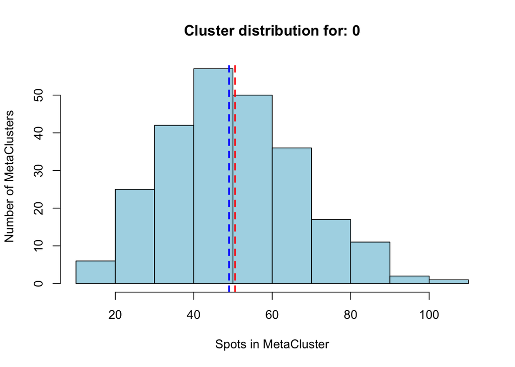

```
## ________________________________________________________________________________
## Number of clusters for 1 : 213
## Cluster distribution:
## clusters
##   0   1   2   3   4   5   6   7   8   9  10  11  12  13  14  15  16  17  18  19
##  89  89  87  86  83  83  83  82  81  81  80  79  77  77  77  76  75  73  73  72
##  20  21  22  23  24  25  26  27  28  29  30  31  32  33  34  35  36  37  38  39
##  71  71  70  70  70  69  69  69  69  68  68  68  68  68  67  65  65  65  65  65
##  40  41  42  43  44  45  46  47  48  49  50  51  52  53  54  55  56  57  58  59
##  65  65  65  64  64  64  63  63  62  62  61  61  61  61  60  60  60  60  59  59
##  60  61  62  63  64  65  66  67  68  69  70  71  72  73  74  75  76  77  78  79
##  59  59  59  59  59  59  58  58  58  57  57  57  56  56  56  56  56  55  55  55
##  80  81  82  83  84  85  86  87  88  89  90  91  92  93  94  95  96  97  98  99
##  55  55  55  55  55  54  54  54  54  54  54  54  54  53  53  53  53  53  53  53
## 100 101 102 103 104 105 106 107 108 109 110 111 112 113 114 115 116 117 118 119
##  52  52  52  52  52  52  51  51  51  51  51  51  50  50  50  50  50  50  50  50
## 120 121 122 123 124 125 126 127 128 129 130 131 132 133 134 135 136 137 138 139
##  50  49  49  49  49  48  48  48  47  47  47  47  47  46  46  45  45  45  45  44
## 140 141 142 143 144 145 146 147 148 149 150 151 152 153 154 155 156 157 158 159
##  44  44  44  43  43  43  43  43  43  42  42  42  42  42  42  42  41  41  41  40
## 160 161 162 163 164 165 166 167 168 169 170 171 172 173 174 175 176 177 178 179
##  40  40  40  39  38  38  37  37  37  36  35  35  34  34  33  32  32  32  31  31
## 180 181 182 183 184 185 186 187 188 189 190 191 192 193 194 195 196 197 198 199
##  31  31  31  31  30  30  30  29  29  29  28  26  26  26  26  25  24  24  24  24
## 200 201 202 203 204 205 206 207 208 209 210 211 212
##  24  24  23  22  21  21  17  16  16  15  15   9   7
```

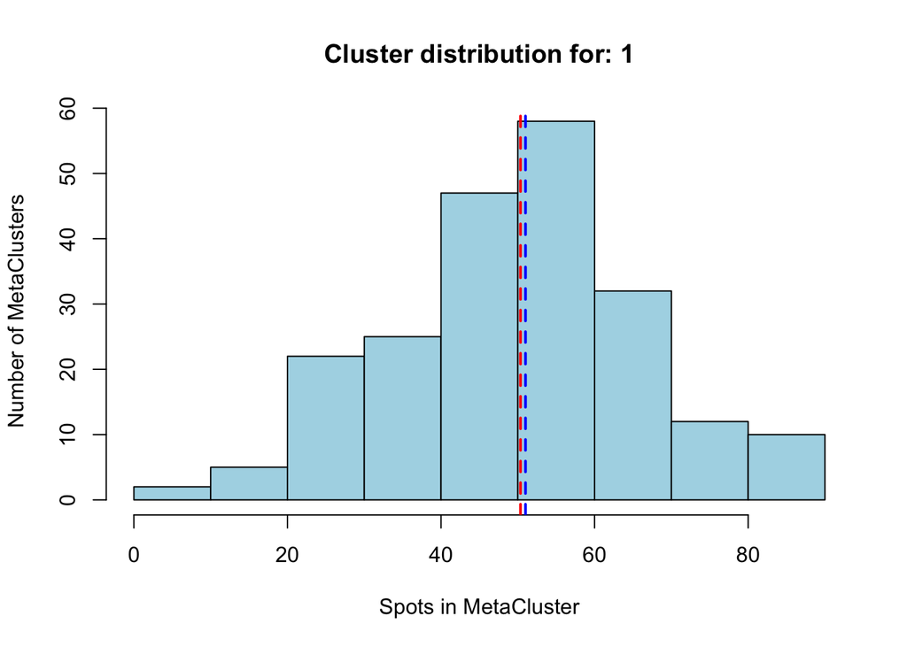

```
## ________________________________________________________________________________
## Number of clusters for 10 : 77
## Cluster distribution:
## clusters
##   0   1   2   3   4   5   6   7   8   9  10  11  12  13  14  15  16  17  18  19
## 108  87  78  73  72  71  69  69  68  64  63  63  62  60  60  60  59  59  59  59
##  20  21  22  23  24  25  26  27  28  29  30  31  32  33  34  35  36  37  38  39
##  59  59  58  58  58  58  57  56  56  55  53  52  52  51  51  51  51  50  49  49
##  40  41  42  43  44  45  46  47  48  49  50  51  52  53  54  55  56  57  58  59
##  49  48  48  47  47  46  46  46  45  44  44  43  43  43  42  42  42  41  41  39
##  60  61  62  63  64  65  66  67  68  69  70  71  72  73  74  75  76
##  39  38  38  37  37  37  37  36  33  31  30  30  29  25  19  16   6
```

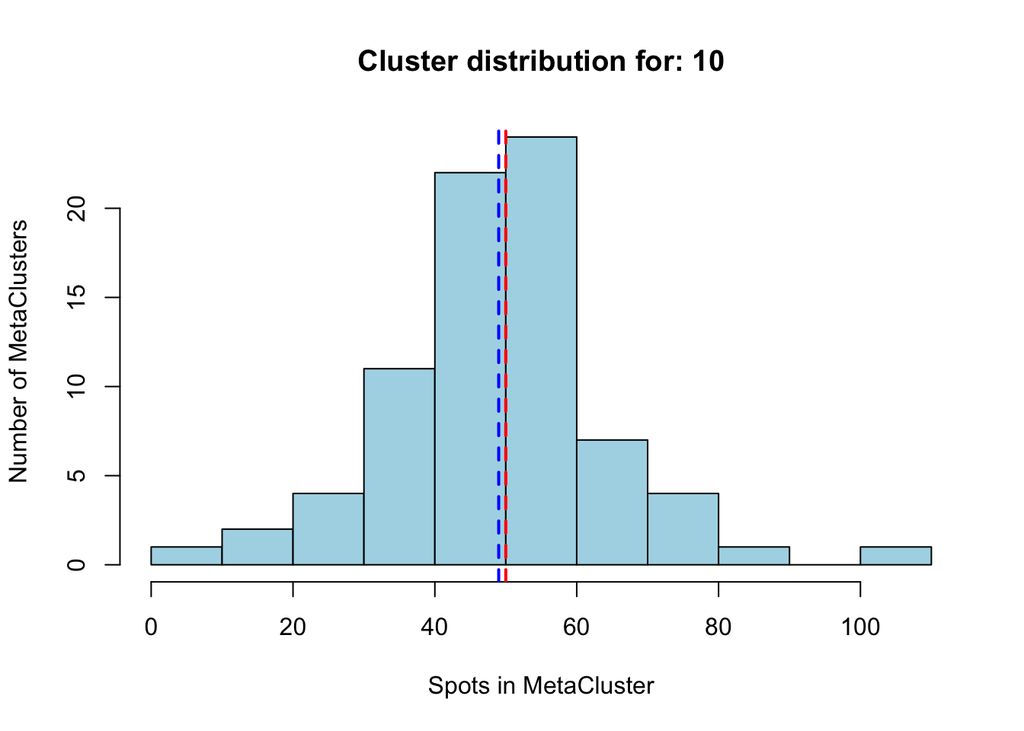

```
## ________________________________________________________________________________
## Number of clusters for 11 : 74
## Cluster distribution:
## clusters
##  0  1  2  3  4  5  6  7  8  9 10 11 12 13 14 15 16 17 18 19 20 21 22 23 24 25
## 90 85 81 77 76 74 74 72 70 69 69 68 67 67 66 66 65 64 63 63 63 63 61 61 60 59
## 26 27 28 29 30 31 32 33 34 35 36 37 38 39 40 41 42 43 44 45 46 47 48 49 50 51
## 59 59 59 57 57 56 55 55 54 53 53 52 51 51 51 49 47 46 46 45 45 45 44 44 44 42
## 52 53 54 55 56 57 58 59 60 61 62 63 64 65 66 67 68 69 70 71 72 73
## 41 41 41 40 37 34 33 32 32 32 31 30 30 30 28 23 20 17 17 13  4  3
```

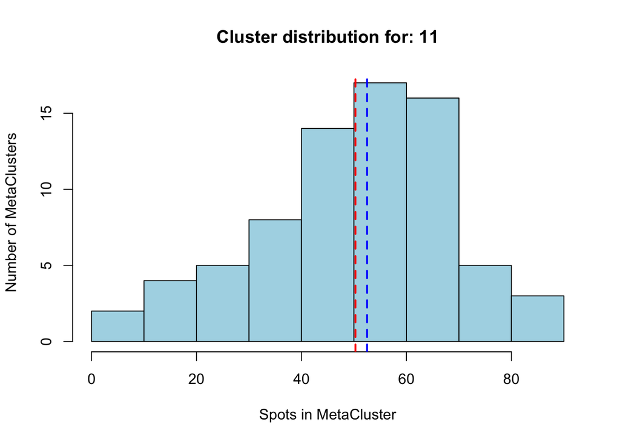

```
## ________________________________________________________________________________
## Number of clusters for 12 : 70
## Cluster distribution:
## clusters
##  0  1  2  3  4  5  6  7  8  9 10 11 12 13 14 15 16 17 18 19 20 21 22 23 24 25
## 86 85 79 78 76 76 75 74 71 71 71 70 69 68 68 66 65 62 60 60 60 60 59 59 58 58
## 26 27 28 29 30 31 32 33 34 35 36 37 38 39 40 41 42 43 44 45 46 47 48 49 50 51
## 56 54 54 54 53 52 52 51 51 51 50 50 48 48 47 47 46 45 45 44 44 42 41 41 41 40
## 52 53 54 55 56 57 58 59 60 61 62 63 64 65 66 67 68 69
## 39 39 38 37 37 35 34 34 34 34 34 33 32 24 20 17 14 11
```

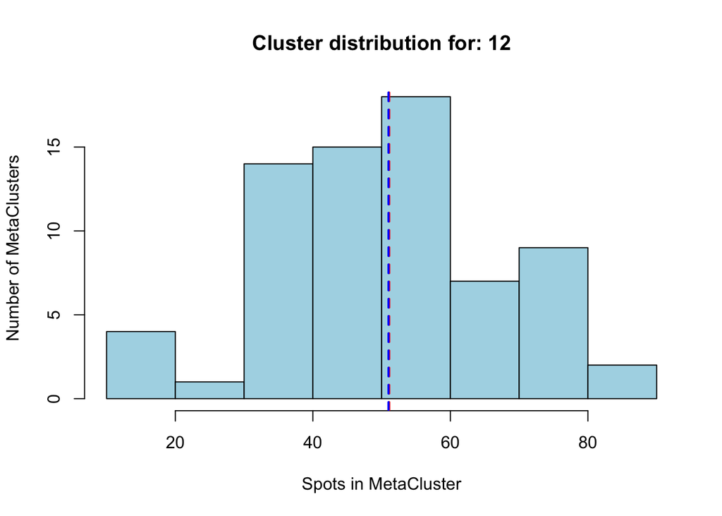

```
## ________________________________________________________________________________
## Number of clusters for 13 : 55
## Cluster distribution:
## clusters
##  0  1  2  3  4  5  6  7  8  9 10 11 12 13 14 15 16 17 18 19 20 21 22 23 24 25
## 85 85 84 84 82 82 79 77 70 68 68 65 65 63 63 61 60 58 58 58 57 56 54 54 54 53
## 26 27 28 29 30 31 32 33 34 35 36 37 38 39 40 41 42 43 44 45 46 47 48 49 50 51
## 53 52 52 50 45 45 45 44 44 43 42 41 41 39 38 37 37 37 35 34 33 33 32 31 31 29
## 52 53 54
## 21 19 17
```

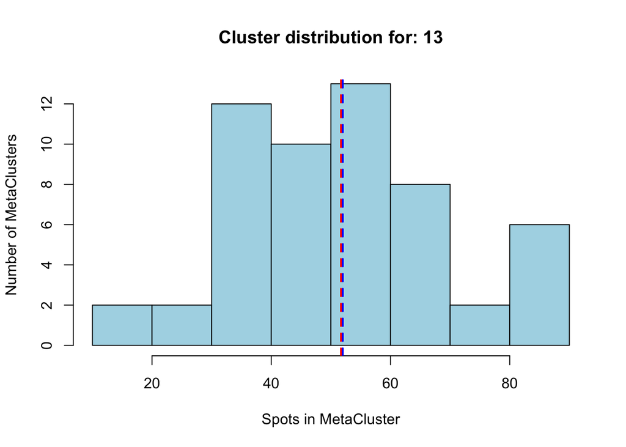

```
## ________________________________________________________________________________
## Number of clusters for 14 : 44
## Cluster distribution:
## clusters
##  0  1  2  3  4  5  6  7  8  9 10 11 12 13 14 15 16 17 18 19 20 21 22 23 24 25
## 91 79 77 74 70 67 67 64 64 63 62 61 61 60 60 60 60 59 57 57 56 56 55 55 54 54
## 26 27 28 29 30 31 32 33 34 35 36 37 38 39 40 41 42 43
## 51 50 48 44 41 41 40 39 38 35 34 34 28 25 24 18 13 12
```

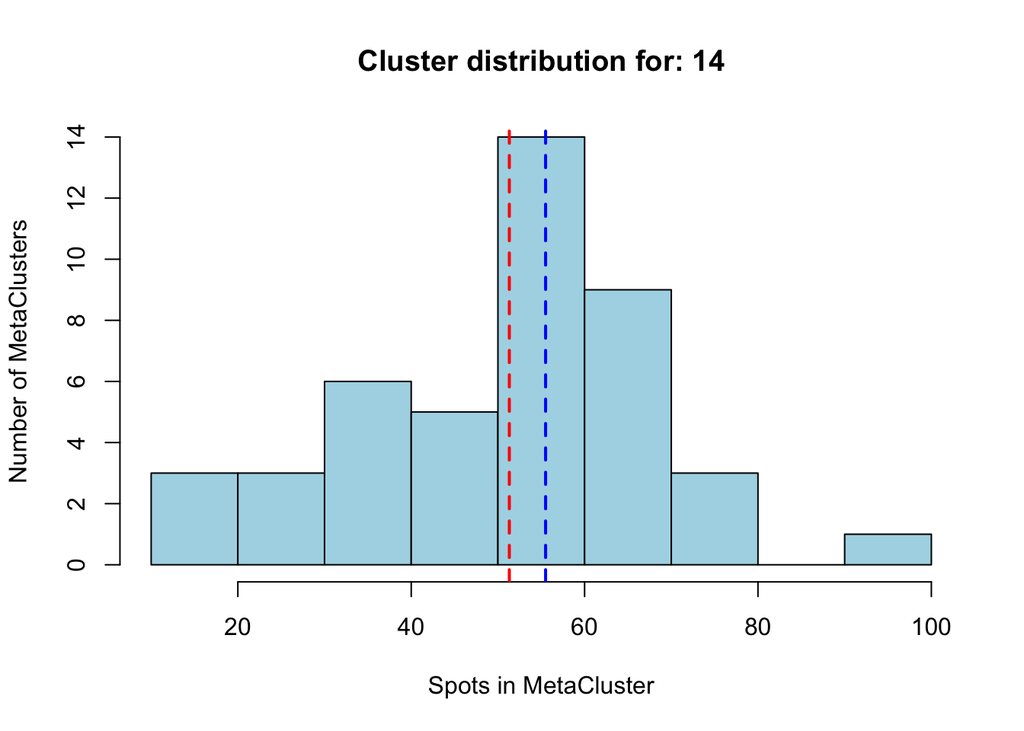

```
## ________________________________________________________________________________
## Number of clusters for 15 : 43
## Cluster distribution:
## clusters
##  0  1  2  3  4  5  6  7  8  9 10 11 12 13 14 15 16 17 18 19 20 21 22 23 24 25
## 88 88 78 78 75 75 71 67 67 66 65 62 62 62 62 61 61 59 59 57 56 55 55 54 47 47
## 26 27 28 29 30 31 32 33 34 35 36 37 38 39 40 41 42
## 46 43 42 40 38 37 36 35 34 32 32 32 31 28 28 24 10
```

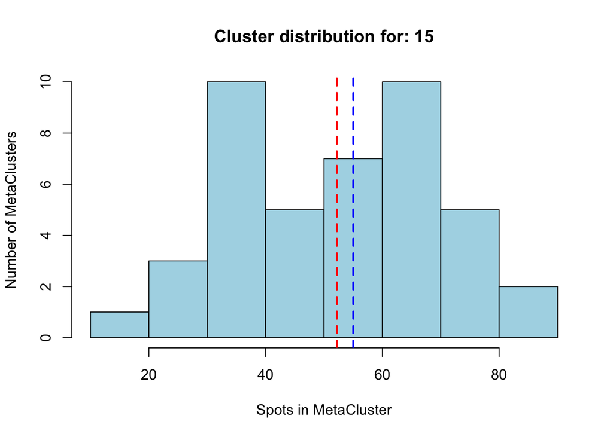

```
## ________________________________________________________________________________
## Number of clusters for 16 : 43
## Cluster distribution:
## clusters
##  0  1  2  3  4  5  6  7  8  9 10 11 12 13 14 15 16 17 18 19 20 21 22 23 24 25
## 85 81 77 73 71 71 71 70 69 68 64 63 59 59 59 57 57 55 54 53 53 50 50 47 45 44
## 26 27 28 29 30 31 32 33 34 35 36 37 38 39 40 41 42
## 43 42 40 40 39 37 37 37 36 35 35 33 32 30 21 20 17
```

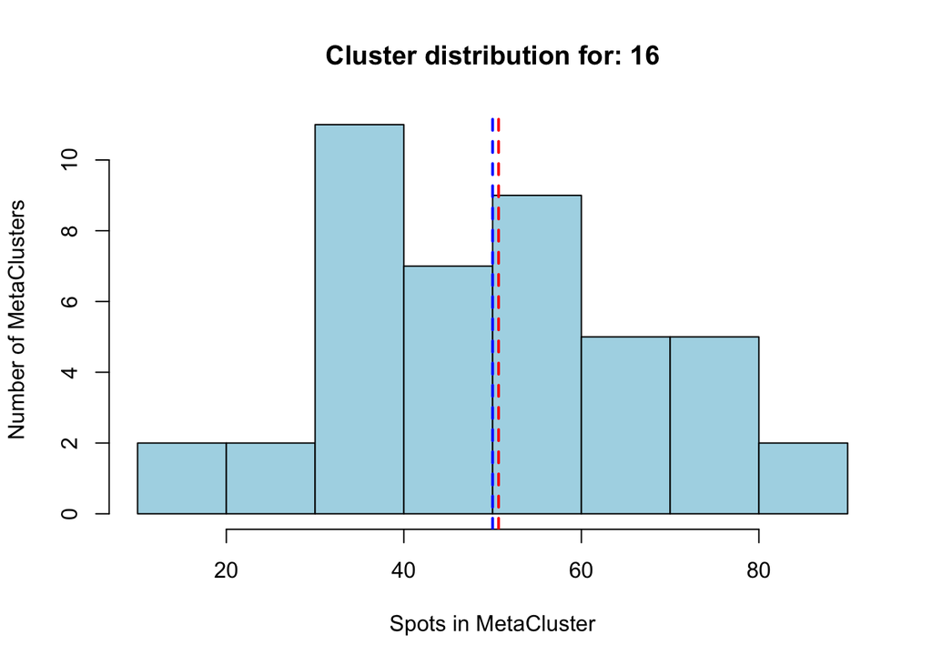

```
## ________________________________________________________________________________
## Number of clusters for 17 : 43
## Cluster distribution:
## clusters
##  0  1  2  3  4  5  6  7  8  9 10 11 12 13 14 15 16 17 18 19 20 21 22 23 24 25
## 79 77 76 75 72 72 69 67 65 62 62 61 61 60 59 59 56 55 54 54 53 50 50 50 50 44
## 26 27 28 29 30 31 32 33 34 35 36 37 38 39 40 41 42
## 43 43 41 39 39 37 36 36 36 35 34 32 30 27 25 14 13
```

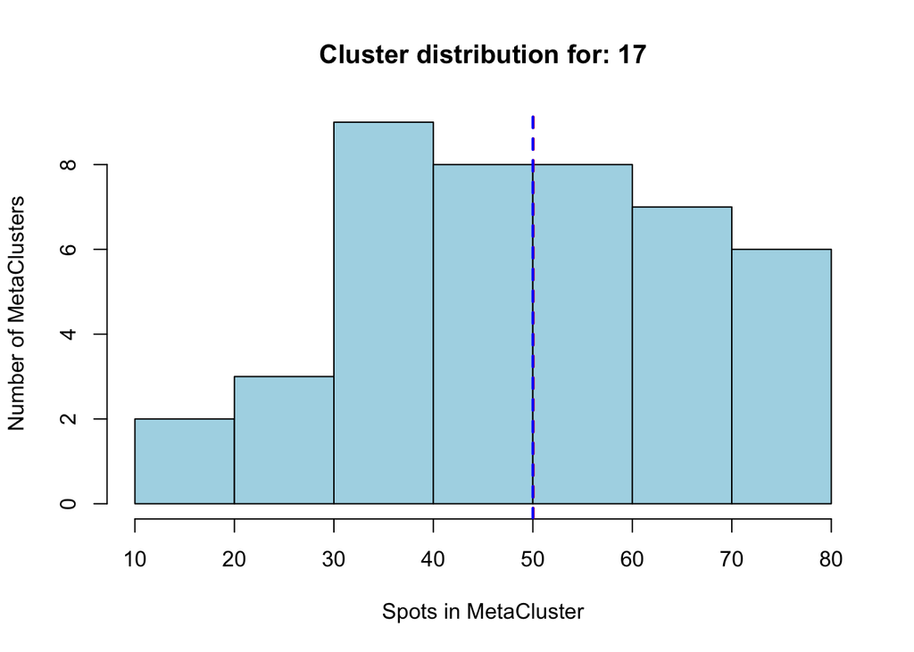

```
## ________________________________________________________________________________
## Number of clusters for 18 : 35
## Cluster distribution:
## clusters
##  0  1  2  3  4  5  6  7  8  9 10 11 12 13 14 15 16 17 18 19 20 21 22 23 24 25
## 98 82 70 69 68 67 64 64 63 62 62 62 56 53 53 52 51 50 49 46 45 44 44 42 42 41
## 26 27 28 29 30 31 32 33 34
## 40 39 38 35 32 29 27 25 18
```

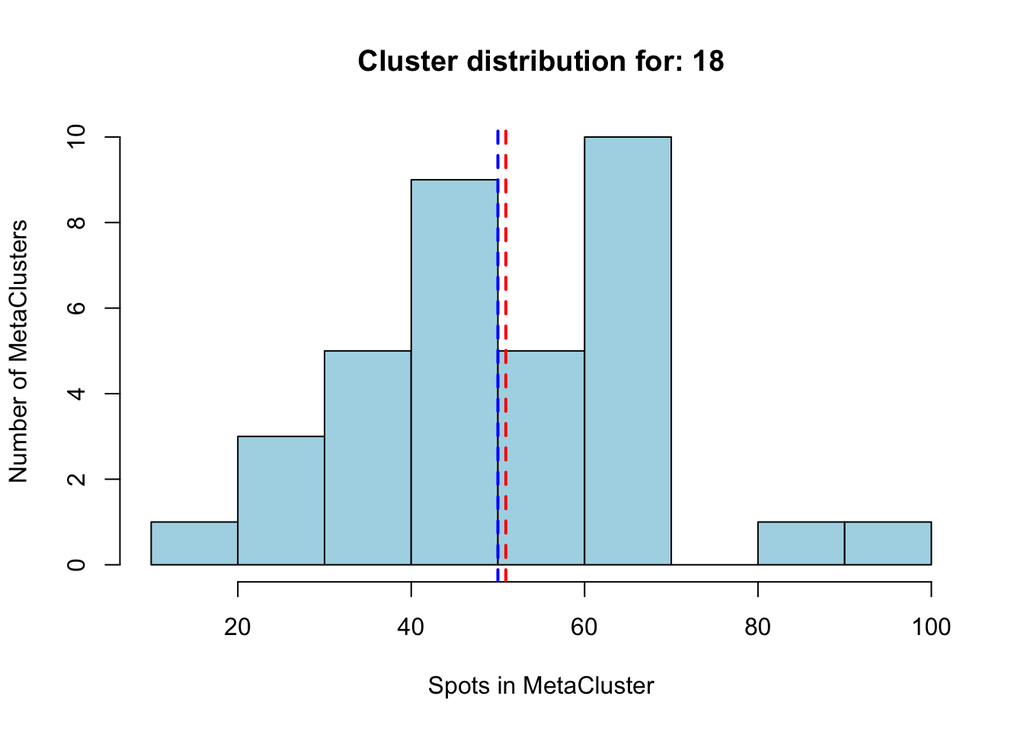

```
## ________________________________________________________________________________
## Number of clusters for 19 : 33
## Cluster distribution:
## clusters
##  0  1  2  3  4  5  6  7  8  9 10 11 12 13 14 15 16 17 18 19 20 21 22 23 24 25
## 76 70 70 70 68 66 65 65 63 62 61 61 57 56 56 55 53 51 49 48 48 47 46 42 41 41
## 26 27 28 29 30 31 32
## 40 37 37 33 32 21 10
```

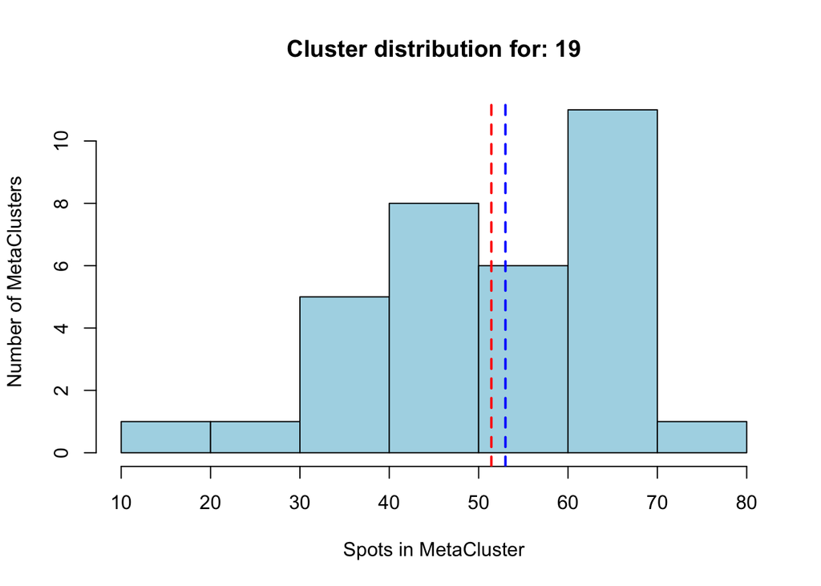

```
## ________________________________________________________________________________
## Number of clusters for 2 : 210
## Cluster distribution:
## clusters
##   0   1   2   3   4   5   6   7   8   9  10  11  12  13  14  15  16  17  18  19
## 101 100  98  97  95  91  90  87  83  80  79  79  79  77  74  73  73  73  72  72
##  20  21  22  23  24  25  26  27  28  29  30  31  32  33  34  35  36  37  38  39
##  71  71  71  70  70  69  69  69  69  68  68  68  68  68  67  67  67  66  66  66
##  40  41  42  43  44  45  46  47  48  49  50  51  52  53  54  55  56  57  58  59
##  65  65  65  64  64  64  63  63  63  63  62  62  62  62  62  62  62  62  61  61
##  60  61  62  63  64  65  66  67  68  69  70  71  72  73  74  75  76  77  78  79
##  61  61  61  60  60  60  59  59  58  58  58  58  58  58  57  57  57  57  57  56
##  80  81  82  83  84  85  86  87  88  89  90  91  92  93  94  95  96  97  98  99
##  56  56  56  55  55  55  55  55  54  54  54  54  54  54  52  52  51  51  51  51
## 100 101 102 103 104 105 106 107 108 109 110 111 112 113 114 115 116 117 118 119
##  51  51  50  49  49  49  49  48  48  48  48  48  48  48  48  48  47  47  47  47
## 120 121 122 123 124 125 126 127 128 129 130 131 132 133 134 135 136 137 138 139
##  46  46  46  46  46  46  45  45  45  45  45  45  45  45  44  44  44  44  44  44
## 140 141 142 143 144 145 146 147 148 149 150 151 152 153 154 155 156 157 158 159
##  43  43  42  42  42  41  41  41  41  41  41  41  40  40  40  39  39  39  39  39
## 160 161 162 163 164 165 166 167 168 169 170 171 172 173 174 175 176 177 178 179
##  38  38  38  38  38  38  38  38  38  38  38  38  37  37  37  36  36  36  35  35
## 180 181 182 183 184 185 186 187 188 189 190 191 192 193 194 195 196 197 198 199
##  35  35  33  32  32  31  31  31  29  29  28  28  26  26  25  22  22  22  22  21
## 200 201 202 203 204 205 206 207 208 209
##  21  21  21  20  20  20  18  18  18  15
```

[12 more figures not shown]

```
## ________________________________________________________________________________
```

```r
plot_metaclusters(metaspots, show_mean = T, show_median = T)
```

# 4 Aggregrate MetaSpot clusters

Aggregates the expression data within spatial clusters (MetaSpots/MetaBins) by summing counts within each sub-cluster of each spatial cluster, and create a MetaSpot/MetaBin Seurat object.

```r
metaspot_seurat <- aggregate_metacells(cell_type_clusters = metaspots$metacells, cluster_col = "cluster_anno")
table(metaspot_seurat$cluster_anno)
```

```
##
##   0   1  10  11  12  13  14  15  16  17  18  19   2  20  21  22  23   3   4   5
## 247 213  77  74  70  55  44  43  43  43  35  33 210  25  20  20  14 207 159 149
##   6   7   8   9
## 149 110 109  83
```

```r
metaspot_seurat
```

```
## An object of class Seurat
## 16082 features across 2232 samples within 1 assay
## Active assay: RNA (16082 features, 0 variable features)
##  24 layers present: counts.1.1.1.1.1.1.1.1.1.1.1.1.1.1.1.1.1.1.1.1.1.1.1, counts.2, counts.2.1, counts.2.1.1, counts.2.1.1.1, counts.2.1.1.1.1, counts.2.1.1.1.1.1, counts.2.1.1.1.1.1.1, counts.2.1.1.1.1.1.1.1, counts.2.1.1.1.1.1.1.1.1, counts.2.1.1.1.1.1.1.1.1.1, counts.2.1.1.1.1.1.1.1.1.1.1, cou…
```

Check number of Genes and UMIs per spatial cluster (MetaSpot/MetaBin data).

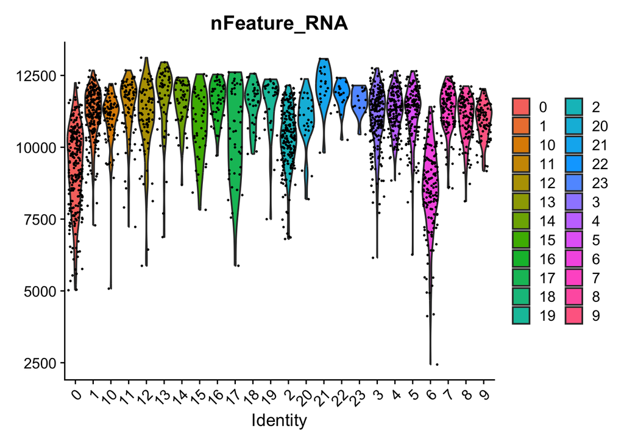

```r
VlnPlot(metaspot_seurat, features = c("nFeature_RNA"), group.by = "cluster_anno")
```

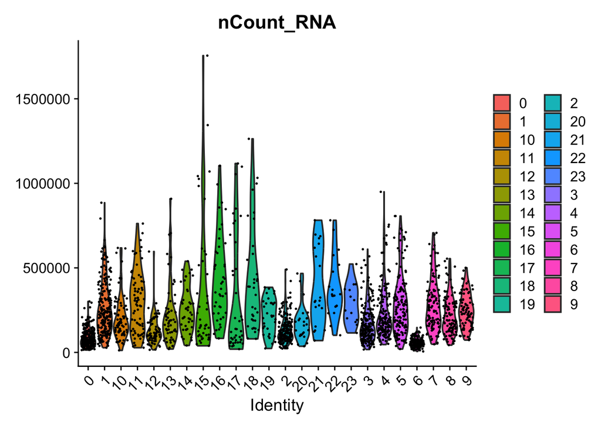

```r
VlnPlot(metaspot_seurat, features = c("nCount_RNA"), group.by = "cluster_anno")
```

Save the MetaSpot/MetaBin Seurat object for downstream analysis!

```r
saveRDS(metaspot_seurat, file = "data/Visium_HD_mouse_coronal/metaspot_seurat.rds")
```

Normalize data with SCTransform.

```r
options(future.globals.maxSize = 4 * 1024^3)
metaspot_seurat <- JoinLayers(metaspot_seurat)
metaspot_seurat_normalized <- SCTransform(metaspot_seurat,assay = "RNA",return.only.var.genes = T)
```

```r
metaspot_seurat_normalized
```

```
## An object of class Seurat
## 32164 features across 2232 samples within 2 assays
## Active assay: SCT (16082 features, 3000 variable features)
##  3 layers present: counts, data, scale.data
##  1 other assay present: RNA
```

Save the normalized MetaSpot/MetaBin Seurat object for downstream analysis!

```r
saveRDS(metaspot_seurat_normalized, file = "data/Visium_HD_mouse_coronal/metaspot_seurat_normalized.rds")
```